# Personnes_agees

Dans ce cadre, serait-il ainsi possible à travers une requête RPU d’avoir des données concernant : - le nombre de passages en 2013 et en 2014 (jusqu’au mois de novembre) selon différentes classes d’âge suivantes:

```
- entre >= 55 et <65 ans
- entre >=65 et <75 ans
- entre >=75 et <85 ans
- >=85 ans.
en les rapportant au total de passages.
```

- le mode d’arrivée et l’origine (mais il me semble qu’à travers les RPU, on ne peut avoir l’information origine domicile/EHPAD…?) (selon les classes d’âge ci-dessus si possible)
- leur orientation à l’issue du passage aux urgences (selon les classes d’âge ci-dessus si possible)
- des informations à travers les motifs et/ou les diagnostics (chute/trouble de la marche/trouble de l’équilibre) en regroupant certains codes ?

# Codes CIM 10

## Chutes

Y30 Chute, saut ou précipitation dans le vide, intention non déterminée, chute de la victime d’un niveau à un autre, intention non déterminée

```
            Y30.0   Chute au domicile
                Y30.1   Chute dans un établissement collectif
                Y30.2   Chute dans une institution
                Y30.3   Chute dans un lieu de sport
                Y30.4   Chute sur la route
                Y30.5   Chute, saut ou précipitation dans le vide, intention non déterminée, dans une zone de commerce et de services
                Y30.6   Chute, saut ou précipitation dans le vide, intention non déterminée, dans un local industriel et chantier de construction
                Y30.7   Chute, saut ou précipitation dans le vide, intention non déterminée, dans une exploitation agricole
                Y30.8   Chute
                Y30.9   Chute
```

## Traumatisme

```
    S00-S09 Lésions traumatiques de la tête
        S10-S19 Lésions traumatiques du cou
        S20-S29 Lésions traumatiques du thorax
        S30-S39 Lésions traumatiques de l'abdomen, des lombes, du rachis lombaire et du bassin
        S40-S49 Lésions traumatiques de l'épaule et du bras
        S50-S59 Lésions traumatiques du coude et de l'avant-bras
        S60-S69 Lésions traumatiques du poignet et de la main
        S70-S79 Lésions traumatiques de la hanche et de la cuisse
        S80-S89 Lésions traumatiques du genou et de la jambe
        S90-S99 Lésions traumatiques de la cheville et du pied
        T00-T07 Lésions traumatiques de plusieurs parties du corps
        T08-T14 Lésions traumatiques de siège non précisé du tronc, membre ou autre région du corps
```

## Définitions

- Domicile: domicile ou ce qui en tient lieu (voie publique)
- Mutation: hospitalisation dans le même établissement que celui du SU
- Transfert: hospitalisation dans un autre établissement que celui du SU.
- PEO: désigne une prise en charge organisationnelle. Ce code est utilisé lorsque le patient n’est pas destiné aux urgences mais il y transite temporairement (par ex. en attente qu’un lit prévu se libère)
- PEA: désigne une arrivée non programmée aux urgences (cas général)

La FEDORU recommande d’identifier les personnes provenant des EHPAD par l’association MODE ENTREE = 8 (Domicile) + PROVENANCE = 7 (structure médico-sociale). Cependant ce dernier code n’est pas proposé dans la version officielle des RPU.

On pourrait identifier indirectement les EHPAD par le mode de sorie: MODE SORTIE = 8 + DESTINATION = 7. Malheureusement l’item DESTINATION est mal renseigné: 21% sur 2 ans (round(mean(!is.na(d2$DESTINATION)) * 100, 2))

## Création des sous groupes

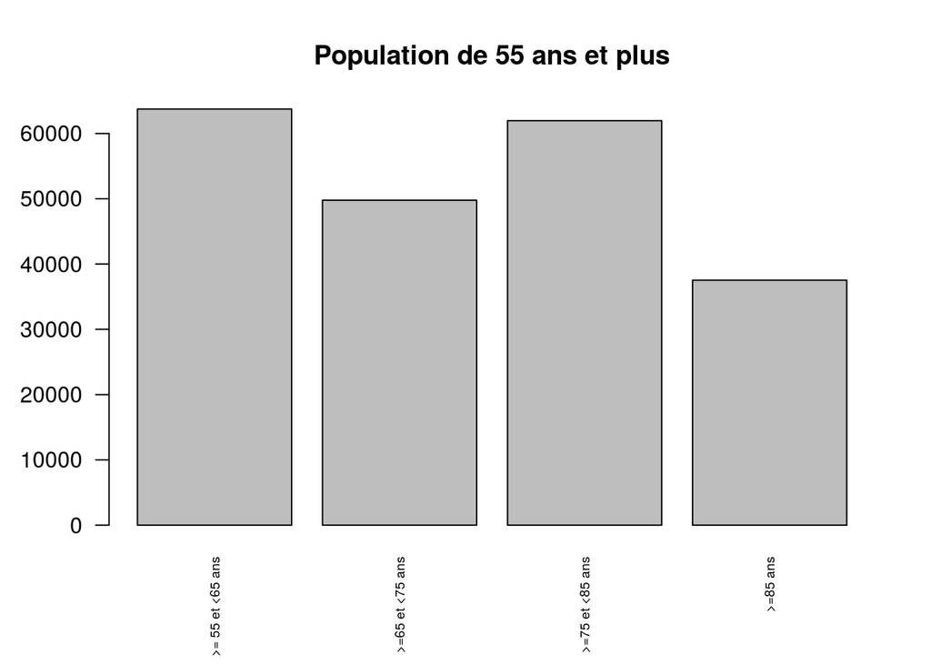

## Résultats

- Date de début: 2013-01-01
- Date de fin: 2014-11-30
- Effectif total: 720164 RPU.
- Nombre de RPU agés de 55 ans ou plus: 219806

#### Complétude des données

Pourcentage de RPU renseignés selon l’item:

- MODE ENTREE: 92 %
- PROVENANCE : 55 %
- MODE SORTIE: 83 %
- DESTINATION: 40 %

|  | &gt = 55 et &lt 65 ans | &gt =65 et &lt 75 ans | &gt =75 et &lt 85 ans | &gt =85 ans |
| --- | --- | --- | --- | --- |
| effectif | 63747.00 | 49777.00 | 61961.00 | 37526.00 |
| % effectif | 29.00 | 22.65 | 28.19 | 17.07 |
| % total RPU | 8.85 | 6.91 | 8.60 | 5.21 |

## Selon le MODE_ENTREE et la PROVENANCE

```
## MODE D'ENTREE
##  Domicile  Mutation Transfert
##    194843      2723      3833
```

```
## PROVENANCE
##   MCO   SSR   SLD   PSY   PEA   PEO
##  7821   105    30    54 95831 17065
```

```
##                   MODE ENTREE
## AGE                Domicile Mutation Transfert
##   >= 55 et <65 ans    57303      575       598
##   >=65 et <75 ans     44614      572       615
##   >=75 et <85 ans     54465      936      1219
##   >=85 ans            32345      590      1338
```

```
##                   PROVENANCE
## AGE                  MCO   SSR   SLD   PSY   PEA   PEO
##   >= 55 et <65 ans  1511     9     0    20 30184  5551
##   >=65 et <75 ans   1427    13     4    15 22168  4323
##   >=75 et <85 ans   2579    41     7    15 25617  4494
##   >=85 ans          2143    41    19     1 14446  2162
```

## Mode de sortie (par classes d’age)

```
## MODE DE SORTIE
##  Mutation Transfert  Domicile     Décès
##     83766      5168     92910         1
```

```
## DESTINATION
##   MCO   SSR   SLD   PSY   HAD   HMS
## 87949   158    41   652     8    24
```

```
## ORIENTATION
##  CHIR FUGUE   HDT    HO   MED  OBST   PSA   REA   REO    SC  SCAM    SI
##  9864    97    63    21 22965    30   859  1432   798   894   311  3146
##  UHCD
## 40474
```

```
##                   MODE DE SORTIE
## AGE                Mutation Transfert Domicile Décès
##   >= 55 et <65 ans    16545      1273    35426     0
##   >=65 et <75 ans     17714      1107    22504     0
##   >=75 et <85 ans     28665      1621    20748     1
##   >=85 ans            19438      1037    10117     0
```

```
##                   DESTINATION
## AGE                  MCO   SSR   SLD   PSY   HAD   HMS
##   >= 55 et <65 ans 17509    19     1   276     3     1
##   >=65 et <75 ans  18631    24     5   139     1     2
##   >=75 et <85 ans  30007    68     8   146     2     6
##   >=85 ans         20313    46    26    57     2    15
```

```
##                   DESTINATION
## AGE                 CHIR FUGUE   HDT    HO   MED  OBST   PSA   REA   REO
##   >= 55 et <65 ans  2455    56    28     8  3822     6   426   403   274
##   >=65 et <75 ans   2066    20    13     4  4759     7   219   409   216
##   >=75 et <85 ans   3048    13    11     7  8338    15   133   456   191
##   >=85 ans          2039     1     7     1  5757     2    37   127    81
##   Sum               9608    90    59    20 22676    30   815  1395   762
##                   DESTINATION
## AGE                   SC  SCAM    SI  UHCD   Sum
##   >= 55 et <65 ans   214   135   669  8247 16743
##   >=65 et <75 ans    206    89   810  8464 17282
##   >=75 et <85 ans    284    53  1110 13365 27024
##   >=85 ans           172    19   505  9690 18438
##   Sum                876   296  3094 39766 79487
```

# Analyse des codes CIM10

```
##    S600    S601    S602 S602 02    S607    S608    S609
##     237      36     621       1       3      30      55
```

## Merging avec le fichier des recours de l’ORUMIP

## Par type d’urgences

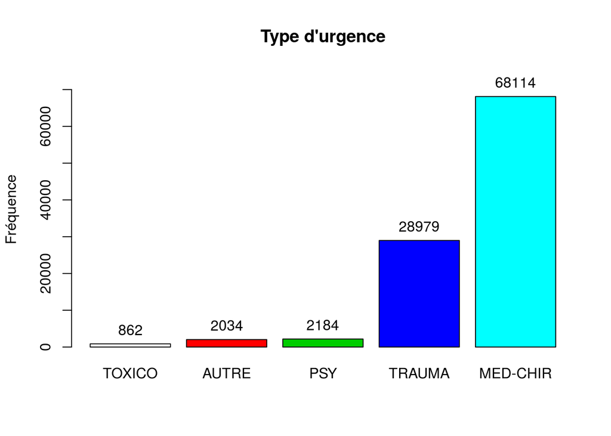

```
## greg$Code.Type.Urgences :
##          Frequency Percent Cum. percent
## TOXICO         862     0.8          0.8
## AUTRE         2034     2.0          2.8
## PSY           2184     2.1          5.0
## TRAUMA       28979    28.4         33.3
## MED-CHIR     68114    66.7        100.0
##   Total     102173   100.0        100.0
```

```
##
##                    AUTRE MED-CHIR   PSY TOXICO TRAUMA
##   >= 55 et <65 ans   738    17107   930    376   9616
##   >=65 et <75 ans    509    15639   493    186   6066
##   >=75 et <85 ans    479    21122   449    171   7134
##   >=85 ans           225    12571   174     68   4969
```

## Traumatologie

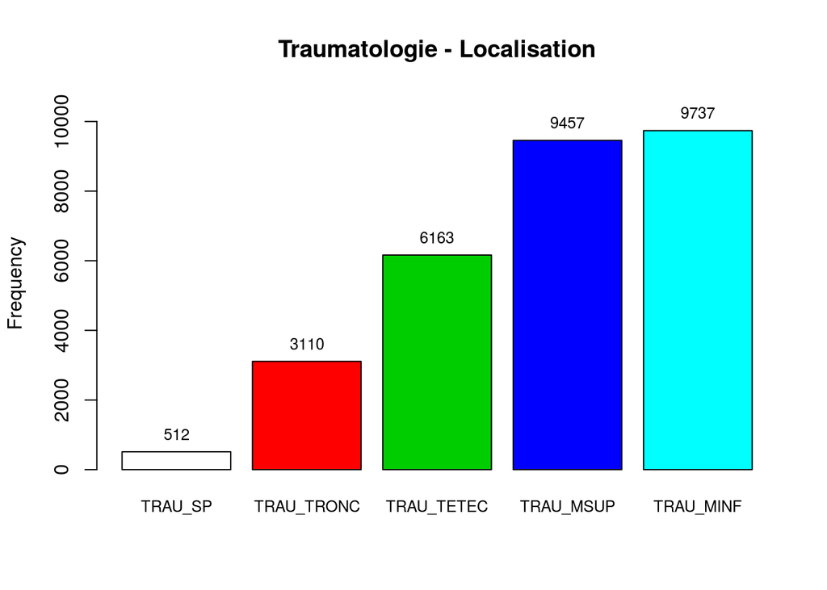

```
## factor(gtrau$Code.Discipline...Topographie) :
##            Frequency Percent Cum. percent
## TRAU_SP          512     1.8          1.8
## TRAU_TRONC      3110    10.7         12.5
## TRAU_TETEC      6163    21.3         33.8
## TRAU_MSUP       9457    32.6         66.4
## TRAU_MINF       9737    33.6        100.0
##   Total        28979   100.0        100.0
```

```
##
##                    TRAU_MINF TRAU_MSUP TRAU_SP TRAU_TETEC TRAU_TRONC
##   >= 55 et <65 ans      3108      3658     192       1713        945
##   >=65 et <75 ans       1958      2149      95       1180        684
##   >=75 et <85 ans       2405      2030     126       1752        821
##   >=85 ans              1863      1177      76       1304        549
```